# Project: No-Show Medical Appointments Analysis

- Introduction
- Data Wrangling
- Exploratory Data Analysis
- Conclusions

## Introduction

This dataset provides the attendance records for more than 100k medical appointments in Brazil, along with some additional characteristics about the appointments and associated patients.

The goal of this analysis is to find remarkable trends in no-show appointments and associated patients so that these trends can be used to predict whether the patient is going to show up for their appointment.

**Questions:**

- Do females skip appointments more than males, or vice versa?
- Is there a specific period of time where the proportion of no-show appointments is significantly higher?
- Is there a certain weekday when the proportion of no-show appointments is unusually higher?
- What is the range of age that shows the highest proportions of no-show appointments?
- Is there a remarkably higher proportion of no-show appointments based on gender and age combined?
- Is there a certain neighbourhoud where the number of no-show appointments is unusually higher?
- Are there specific conditions of patients associated with no-show appointments?
- Is there a lack of SMS messages associated with no-show appointments?

```python
import pandas as pd
import numpy as np
import matplotlib.pyplot as plt
%matplotlib inline
```

## Data Wrangling

### Gathering data

```python
df = pd.read_csv('data.csv')
```

### Assessing data

First look:

```python
df.head()
```

|  | PatientId | AppointmentID | Gender | ScheduledDay | AppointmentDay | Age | Neighbourhood | Scholarship | Hipertension | Diabetes | Alcoholism | Handcap | SMS_received | No-show |
| --- | --- | --- | --- | --- | --- | --- | --- | --- | --- | --- | --- | --- | --- | --- |
| 0 | 2.987250e+13 | 5642903 | F | 2016-04-29T18:38:08Z | 2016-04-29T00:00:00Z | 62 | JARDIM DA PENHA | 0 | 1 | 0 | 0 | 0 | 0 | No |
| 1 | 5.589980e+14 | 5642503 | M | 2016-04-29T16:08:27Z | 2016-04-29T00:00:00Z | 56 | JARDIM DA PENHA | 0 | 0 | 0 | 0 | 0 | 0 | No |
| 2 | 4.262960e+12 | 5642549 | F | 2016-04-29T16:19:04Z | 2016-04-29T00:00:00Z | 62 | MATA DA PRAIA | 0 | 0 | 0 | 0 | 0 | 0 | No |
| 3 | 8.679510e+11 | 5642828 | F | 2016-04-29T17:29:31Z | 2016-04-29T00:00:00Z | 8 | PONTAL DE CAMBURI | 0 | 0 | 0 | 0 | 0 | 0 | No |
| 4 | 8.841190e+12 | 5642494 | F | 2016-04-29T16:07:23Z | 2016-04-29T00:00:00Z | 56 | JARDIM DA PENHA | 0 | 1 | 1 | 0 | 0 | 0 | No |

- Extraneous columns: PatientId, AppointmentID, AppointmentDay
- Incorrect spelling in columns: Hipertension and Handcap

```python
df.shape
```

```
(110527, 14)
```

A brief look at descriptive statistics:

```python
df.describe()
```

|  | PatientId | AppointmentID | Age | Scholarship | Hipertension | Diabetes | Alcoholism | Handcap | SMS_received |
| --- | --- | --- | --- | --- | --- | --- | --- | --- | --- |
| count | 1.105270e+05 | 1.105270e+05 | 110527.000000 | 110527.000000 | 110527.000000 | 110527.000000 | 110527.000000 | 110527.000000 | 110527.000000 |
| mean | 1.474963e+14 | 5.675305e+06 | 37.088874 | 0.098266 | 0.197246 | 0.071865 | 0.030400 | 0.022248 | 0.321026 |
| std | 2.560949e+14 | 7.129575e+04 | 23.110205 | 0.297675 | 0.397921 | 0.258265 | 0.171686 | 0.161543 | 0.466873 |
| min | 3.920000e+04 | 5.030230e+06 | -1.000000 | 0.000000 | 0.000000 | 0.000000 | 0.000000 | 0.000000 | 0.000000 |
| 25% | 4.172615e+12 | 5.640286e+06 | 18.000000 | 0.000000 | 0.000000 | 0.000000 | 0.000000 | 0.000000 | 0.000000 |
| 50% | 3.173180e+13 | 5.680573e+06 | 37.000000 | 0.000000 | 0.000000 | 0.000000 | 0.000000 | 0.000000 | 0.000000 |
| 75% | 9.439170e+13 | 5.725524e+06 | 55.000000 | 0.000000 | 0.000000 | 0.000000 | 0.000000 | 0.000000 | 1.000000 |
| max | 9.999820e+14 | 5.790484e+06 | 115.000000 | 1.000000 | 1.000000 | 1.000000 | 1.000000 | 4.000000 | 1.000000 |

```python
# checking rows with age less than 0
df[df['Age'] < 0]
```

|  | PatientId | AppointmentID | Gender | ScheduledDay | AppointmentDay | Age | Neighbourhood | Scholarship | Hipertension | Diabetes | Alcoholism | Handcap | SMS_received | No-show |
| --- | --- | --- | --- | --- | --- | --- | --- | --- | --- | --- | --- | --- | --- | --- |
| 99832 | 4.659430e+14 | 5775010 | F | 2016-06-06T08:58:13Z | 2016-06-06T00:00:00Z | -1 | ROMÃO | 0 | 0 | 0 | 0 | 0 | 0 | No |

- Age cannot be a negative value

Checking data types and null values:

```python
df.info()
```

```
<class 'pandas.core.frame.DataFrame'>
RangeIndex: 110527 entries, 0 to 110526
Data columns (total 14 columns):
 #   Column          Non-Null Count   Dtype
---  ------          --------------   -----
 0   PatientId       110527 non-null  float64
 1   AppointmentID   110527 non-null  int64
 2   Gender          110527 non-null  object
 3   ScheduledDay    110527 non-null  object
 4   AppointmentDay  110527 non-null  object
 5   Age             110527 non-null  int64
 6   Neighbourhood   110527 non-null  object
 7   Scholarship     110527 non-null  int64
 8   Hipertension    110527 non-null  int64
 9   Diabetes        110527 non-null  int64
 10  Alcoholism      110527 non-null  int64
 11  Handcap         110527 non-null  int64
 12  SMS_received    110527 non-null  int64
 13  No-show         110527 non-null  object
dtypes: float64(1), int64(8), object(5)
memory usage: 11.8+ MB
```

```python
# checking the type of column 'ScheduledDay' by checking the type of the first value in column
type(df['ScheduledDay'][0])
```

```
str
```

- SchduledDay is of type string instead of datetime

Checking various columns for invalid values:

```python
cols = ['Gender', 'Scholarship', 'Hipertension', 'Diabetes', 'Alcoholism', 'Handcap', 'SMS_received', 'No-show']

for col in cols:
    print(col, df[col].unique())
```

```
Gender ['F' 'M']
Scholarship [0 1]
Hipertension [1 0]
Diabetes [0 1]
Alcoholism [0 1]
Handcap [0 1 2 3 4]
SMS_received [0 1]
No-show ['No' 'Yes']
```

- In Handcap column, there should not be values other than 0 and 1.
- In No-show column, values are 'No' and 'Yes' instead of 0 and 1.

#### Assessment summary:

- Extraneous columns: PatientId, AppointmentID, AppointmentDay
- Incorrect spelling in columns: Hipertension and Handcap
- Age cannot be a negative value
- SchduledDay is of type string instead of datetime
- In Handcap column, there should not be values other than 0 and 1.
- In No-show column, values are 'No' and 'Yes' instead of 0 and 1.

### Cleaning Data

Drop extraneous columns:

```python
df.drop(['PatientId', 'AppointmentID', 'AppointmentDay'], axis=1, inplace=True)
```

Fix incorrect spellings in columns:

```python
df.rename(columns={
    'Hipertension': 'Hypertension',
    'Handcap': 'Handicap'
}, inplace=True)
```

Drop rows with negative age:

```python
df = df[df['Age'] >= 0]
```

Add column year_month. This makes it easier to group appointments by month later in analysis:

```python
df['year_month'] = df['ScheduledDay'].str.slice(0,7)
df['year_month']
```

```
0         2016-04
1         2016-04
2         2016-04
3         2016-04
4         2016-04
           ...
110522    2016-05
110523    2016-05
110524    2016-04
110525    2016-04
110526    2016-04
Name: year_month, Length: 110526, dtype: object
```

Change the data type of column 'ScheduledDay' from string to datetime:

```python
df['ScheduledDay'] = df['ScheduledDay'].astype(np.datetime64)
```

In column 'Handicap', replace values larger than 1 with 1:

```python
df['Handicap'] = df['Handicap'].apply(lambda v: 1 if v > 1 else v) # apply a function for each value in column
```

In 'No-show' column, change the values 'No' and 'Yes' to 0 and 1. This automatically changes the column's data type to int64:

```python
df['No-show'].replace('No', 0, inplace=True)
df['No-show'].replace('Yes', 1, inplace=True)
```

## Exploratory Data Analysis

Prepare for analysis:

```python
show = df['No-show'] == 0 # mask series for show rows
noshow = df['No-show'] == 1 # mask series for noshow rows
df # get a view of the dataset after cleaning
```

|  | Gender | ScheduledDay | Age | Neighbourhood | Scholarship | Hypertension | Diabetes | Alcoholism | Handicap | SMS_received | No-show | year_month |
| --- | --- | --- | --- | --- | --- | --- | --- | --- | --- | --- | --- | --- |
| 0 | F | 2016-04-29 18:38:08 | 62 | JARDIM DA PENHA | 0 | 1 | 0 | 0 | 0 | 0 | 0 | 2016-04 |
| 1 | M | 2016-04-29 16:08:27 | 56 | JARDIM DA PENHA | 0 | 0 | 0 | 0 | 0 | 0 | 0 | 2016-04 |
| 2 | F | 2016-04-29 16:19:04 | 62 | MATA DA PRAIA | 0 | 0 | 0 | 0 | 0 | 0 | 0 | 2016-04 |
| 3 | F | 2016-04-29 17:29:31 | 8 | PONTAL DE CAMBURI | 0 | 0 | 0 | 0 | 0 | 0 | 0 | 2016-04 |
| 4 | F | 2016-04-29 16:07:23 | 56 | JARDIM DA PENHA | 0 | 1 | 1 | 0 | 0 | 0 | 0 | 2016-04 |
| ... | ... | ... | ... | ... | ... | ... | ... | ... | ... | ... | ... | ... |
| 110522 | F | 2016-05-03 09:15:35 | 56 | MARIA ORTIZ | 0 | 0 | 0 | 0 | 0 | 1 | 0 | 2016-05 |
| 110523 | F | 2016-05-03 07:27:33 | 51 | MARIA ORTIZ | 0 | 0 | 0 | 0 | 0 | 1 | 0 | 2016-05 |
| 110524 | F | 2016-04-27 16:03:52 | 21 | MARIA ORTIZ | 0 | 0 | 0 | 0 | 0 | 1 | 0 | 2016-04 |
| 110525 | F | 2016-04-27 15:09:23 | 38 | MARIA ORTIZ | 0 | 0 | 0 | 0 | 0 | 1 | 0 | 2016-04 |
| 110526 | F | 2016-04-27 13:30:56 | 54 | MARIA ORTIZ | 0 | 0 | 0 | 0 | 0 | 1 | 0 | 2016-04 |

110526 rows × 12 columns

### Do females skip appointments more than males, or vice versa?

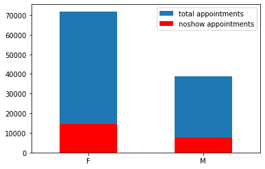

```python
# comparing total appointments and no-show appointments based on gender
df['Gender'].value_counts().plot(kind='bar', rot=0, label='total appointments')
df['Gender'][noshow].value_counts().plot(kind='bar', rot=0, color='red', label='noshow appointments')
plt.legend()
```

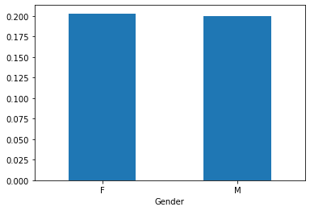

```python
# calculating the proportions of no-show appointments in males and females
df.groupby('Gender')['No-show'].mean().plot(kind='bar', rot=0)
```

- There's no significant difference in proportions of noshow appointments between females and males.

### Is there a specific period of time where the proportion of no-show appointments is significantly higher?

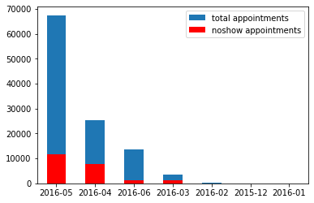

```python
# comparing total appointments and no-show appointments for each month
df['year_month'].value_counts().plot.bar(label='total appointments')
df['year_month'][noshow].value_counts().plot.bar(color='red', rot=0, label='noshow appointments')
plt.legend()
```

- The chart above shows that most appointments were scheduled from March to June 2016.

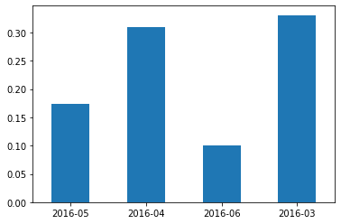

```python
# trimming down selected months to the period of March to June
df_march_june_total = df['year_month'].value_counts()[:-4]
df_march_june_noshow = df['year_month'][noshow].value_counts()[:-3]
# calculate the proportions of no-show appointments in each of the selected months
(df_march_june_noshow / df_march_june_total).plot.bar(rot=0)
```

- By comparing the proportions of noshow appointments of the selected months, it shows that the proportions of no-show appointments in March and April are remarkably higher than May and June.

### Is there a certain weekday when the proportion of no-show appointments is unusually higher?

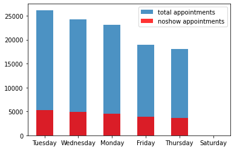

```python
# comparing total appointments and no-show appointments based on weekday
df['ScheduledDay'].dt.day_name().value_counts().plot(kind='bar', alpha=0.8, label='total appointments', rot=0)
df['ScheduledDay'][noshow].dt.day_name().value_counts().plot(kind='bar', alpha=0.8, color='red', label='noshow appointments', rot=0)
plt.legend()
```

- We can exclude Saturday as it has very few appointments as shown in the chart above.

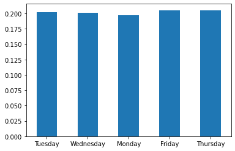

```python
# calculating proportions of no-show appointments per weekday, excluding Saturday
noshow_per_weekday = df['ScheduledDay'][noshow].dt.day_name().value_counts()
total_per_weekday = df['ScheduledDay'].dt.day_name().value_counts()
(noshow_per_weekday / total_per_weekday)[:-1].plot.bar(rot=0)
```

- There's no significant difference between the proportions of no-show appointments of weekdays

### What is the range of age that shows the highest proportions of no-show appointments?

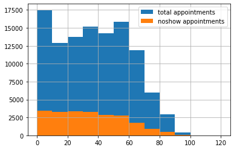

```python
age_bins = np.arange(start=0, stop=130, step=10) # fixed bins for ages
# comparing total appointments with noshow appointments for each age bin
df['Age'].hist(bins=age_bins, label='total appointments')
df['Age'][noshow].hist(bins=age_bins, label='noshow appointments')
plt.legend()
```

- We can exclude ages above 90 since their total appointments count is low

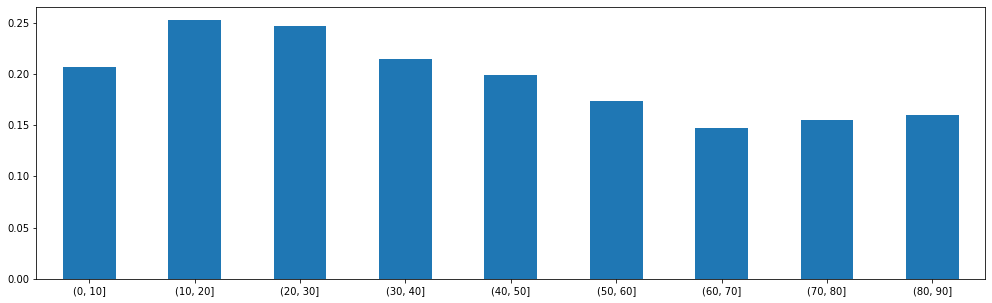

```python
# matching each age to a bin
age_bin_matches = pd.cut(df['Age'], bins=age_bins)
# calculating proportions of no-show appointments for each bin
noshow_proportions_per_age = (age_bin_matches[noshow].value_counts() / age_bin_matches.value_counts())
# Excluding ages over 90
noshow_proportions_per_age = noshow_proportions_per_age[:-3]
# plotting
noshow_proportions_per_age.plot.bar(rot=0, figsize=(17, 5))
```

- We can see that the age range from 10 to 30 has the highest proportion of no-show appointments.

### Is there a remarkably higher proportion of no-show appointments based on gender and age combined?

```python
male = df['Gender'] == 'M'
female = df['Gender'] == 'F'
```

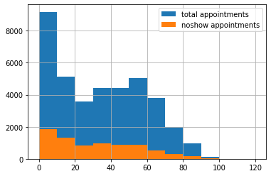

```python
# comparing total appointments and no-show appointments based on male appointments
df['Age'][male].hist(bins=age_bins, label='total appointments')
df['Age'][male * noshow].hist(bins=age_bins, label='noshow appointments')
plt.legend()
```

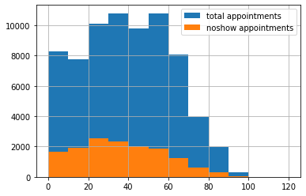

```python
# comparing total appointments and no-show appointments based on female appointments
df['Age'][female].hist(bins=age_bins, label='total appointments')
df['Age'][female * noshow].hist(bins=age_bins, label='noshow appointments')
plt.legend()
```

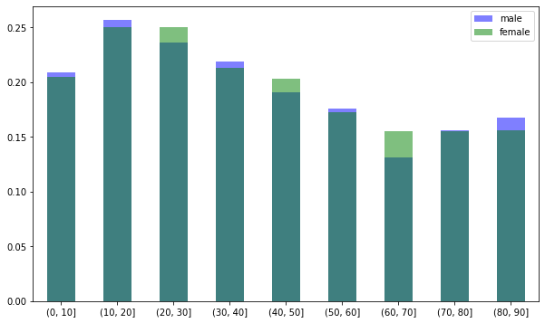

```python
# calculating proportions of no-show appointments in males and females
noshow_proportions_per_age_male = (age_bin_matches[male * noshow].value_counts() / age_bin_matches[male].value_counts())
noshow_proportions_per_age_female = (age_bin_matches[female * noshow].value_counts() / age_bin_matches[female].value_counts())
# excluding ages over 90
noshow_proportions_per_age_male = noshow_proportions_per_age_male[:-3]
noshow_proportions_per_age_female = noshow_proportions_per_age_female[:-3]
# comparing
noshow_proportions_per_age_male.plot.bar(rot=0, figsize=(10,6), color='blue', alpha=0.5, label='male')
noshow_proportions_per_age_female.plot.bar(rot=0, figsize=(10,6), color='green', alpha=0.5, label='female')
plt.legend()
```

- There's no significant difference between no-show proportions based on gender and age

### Is there a certain neighbourhoud where the number of no-show appointments is unusually higher?

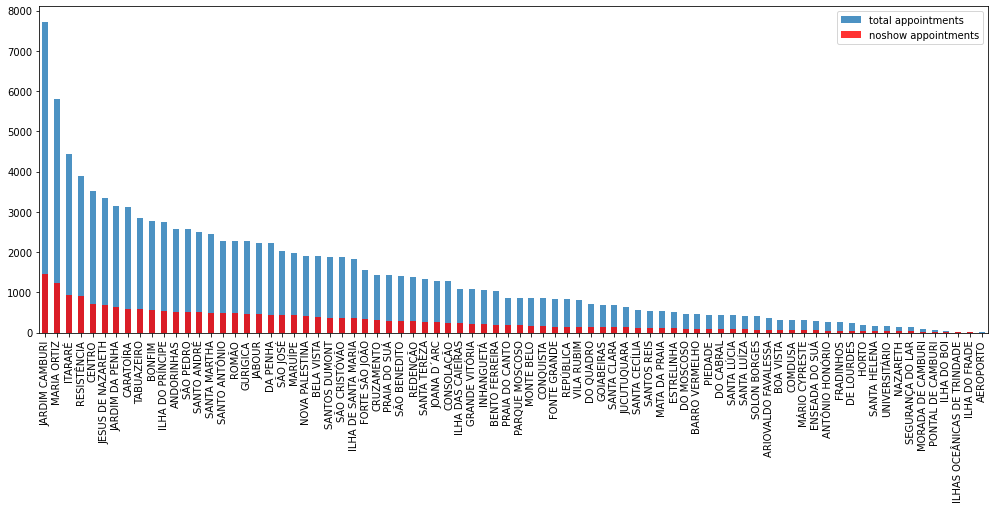

```python
# comparing total appointments and no-show appointments based on neighbourhood
df['Neighbourhood'].value_counts().plot(kind='bar', alpha=0.8, figsize=(17,6), label='total appointments')
df['Neighbourhood'][noshow].value_counts().plot(kind='bar', alpha=0.8, figsize=(17,6), color='red', label='noshow appointments')
plt.legend()
```

- We can exclude neighbourhoods with less than 1000 total appointments to narrow down the focus on important proportions

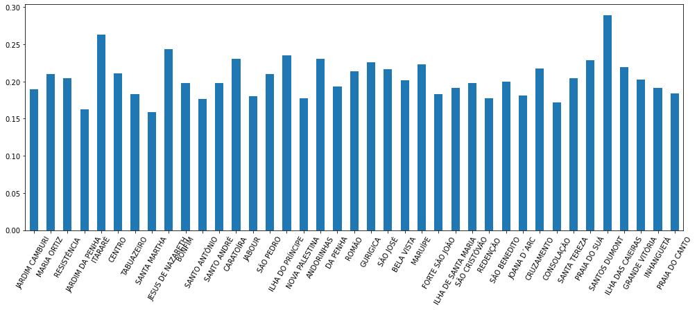

```python
neighbourhood_counts = df['Neighbourhood'].value_counts()
# excluding neighbourhoods that have less than 1000 total appointments
neighbourhood_counts = neighbourhood_counts[neighbourhood_counts >= 1000]


neighbourhood_counts_noshow = df['Neighbourhood'][noshow].value_counts()
# removing values that don't exist in neighbourhood_counts
neighbourhood_counts_noshow = neighbourhood_counts_noshow.loc[neighbourhood_counts.index]


#plotting no-show proportions per neighbourhood
(neighbourhood_counts_noshow / neighbourhood_counts).plot.bar(figsize=(17,6),rot=60)
```

### Are there specific conditions of patients associated with no-show appointments?

Checking enrollment in Bolsa Familia welfare scholarship across no-show apppointments:

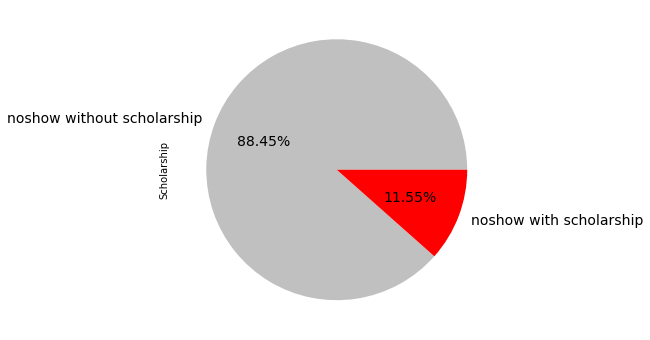

```python
df[noshow]['Scholarship'].value_counts().plot(
    #attributes used from pandas docs https://pandas.pydata.org/pandas-docs/stable/user_guide/visualization.html#pie-plot
    kind='pie',
    autopct="%.2f%%",
    colors=['silver','red'], # list of named colors: https://matplotlib.org/stable/gallery/color/named_colors.html
    labels=['noshow without scholarship', 'noshow with scholarship'],
    fontsize=14,
    figsize=(12,6)
)
```

Checking proportion of patients with hypertension across no-show apppointments:

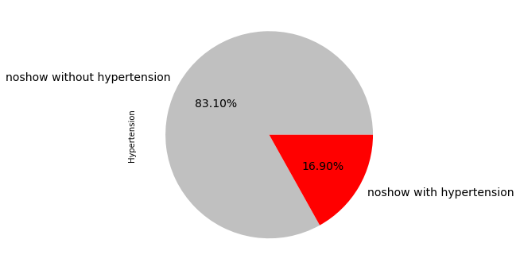

```python
df['Hypertension'][noshow].value_counts().plot(
    #attributes used from pandas docs https://pandas.pydata.org/pandas-docs/stable/user_guide/visualization.html#pie-plot
    kind='pie',
    autopct="%.2f%%",
    colors=['silver','red'], # list of named colors: https://matplotlib.org/stable/gallery/color/named_colors.html
    labels=['noshow without hypertension', 'noshow with hypertension'],
    fontsize=14,
    figsize=(12,6)
)
```

Checking proportion of patients with diabetes across no-show apppointments:

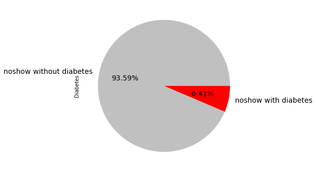

```python
df['Diabetes'][noshow].value_counts().plot(
    #attributes used from pandas docs https://pandas.pydata.org/pandas-docs/stable/user_guide/visualization.html#pie-plot
    kind='pie',
    autopct="%.2f%%",
    colors=['silver','red'], # list of named colors: https://matplotlib.org/stable/gallery/color/named_colors.html
    labels=['noshow without diabetes', 'noshow with diabetes'],
    fontsize=14,
    figsize=(12,6)
)
```

Checking proportion of patients with alcoholism across no-show apppointments:

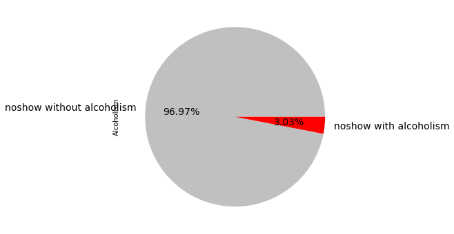

```python
df['Alcoholism'][noshow].value_counts().plot(
    #attributes used from pandas docs https://pandas.pydata.org/pandas-docs/stable/user_guide/visualization.html#pie-plot
    kind='pie',
    autopct="%.2f%%",
    colors=['silver','red'], # list of named colors: https://matplotlib.org/stable/gallery/color/named_colors.html
    labels=['noshow without alcoholism', 'noshow with alcoholism'],
    fontsize=14,
    figsize=(12,6)
)
```

Checking proportion of patients with handicap conditions across no-show apppointments:

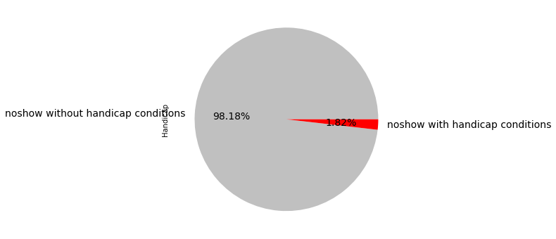

```python
df['Handicap'][noshow].value_counts().plot(
    #attributes used from pandas docs https://pandas.pydata.org/pandas-docs/stable/user_guide/visualization.html#pie-plot
    kind='pie',
    autopct="%.2f%%",
    colors=['silver','red'], # list of named colors: https://matplotlib.org/stable/gallery/color/named_colors.html
    labels=['noshow without handicap conditions', 'noshow with handicap conditions'],
    fontsize=14,
    figsize=(12,6)
)
```

### Is there a lack of SMS messages associated with no-show appointments?

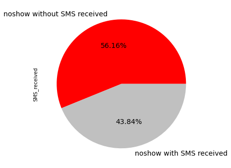

```python
df['SMS_received'][noshow].value_counts().plot(
    #attributes used from pandas docs https://pandas.pydata.org/pandas-docs/stable/user_guide/visualization.html#pie-plot
    kind='pie',
    autopct="%.2f%%",
    colors=['red','silver'], # list of named colors: https://matplotlib.org/stable/gallery/color/named_colors.html
    labels=['noshow without SMS received', 'noshow with SMS received'],
    fontsize=14,
    figsize=(12,6)
)
```

## Conclusions

In this analysis, we explored a dataset of more than 100k records of medical appointments and answered the following questions:

### Limitations

- Removed one row contains negative age.
- The "handicap" column had invalid values (values other than 0 and 1) that were replaced with 1.
- In order for proportions to be meaningful, we excluded some values where the total number of appointments is not large enough to be significant. This is also noted with the visualizations below.

### Is there a specific period of time where the proportion of no-show appointments is significantly higher?

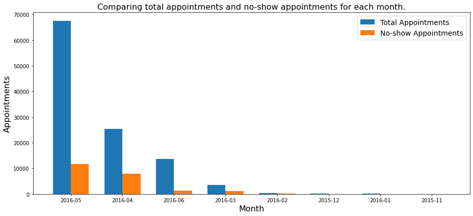

```python
total_appointments = df['year_month'].value_counts()
noshow_appointments = df['year_month'][noshow].value_counts()
noshow_appointments['2015-11'] = 0 # adding last value for shapes to match in plot
labels = list(total_appointments.index)

x = np.arange(len(labels))  # the label locations
width = 0.35  # the width of the bars

fig, ax = plt.subplots(figsize=(13,6))
rects1 = ax.bar(x - width/2, total_appointments.values, width, label='Total Appointments')
rects2 = ax.bar(x + width/2, noshow_appointments.values, width, label='No-show Appointments')

# Add some text for labels, title and custom x-axis tick labels, etc.
ax.set_ylabel('Appointments', fontdict={'fontsize':16})
ax.set_xlabel('Month', fontdict={'fontsize':16})
ax.set_title('Comparing total appointments and no-show appointments for each month.', fontdict={'fontsize':16})
ax.set_xticks(ticks=x, labels=labels)
ax.legend(fontsize=14)


fig.tight_layout()

plt.show()
```

- The chart above shows that most appointments were scheduled from March to June 2016.

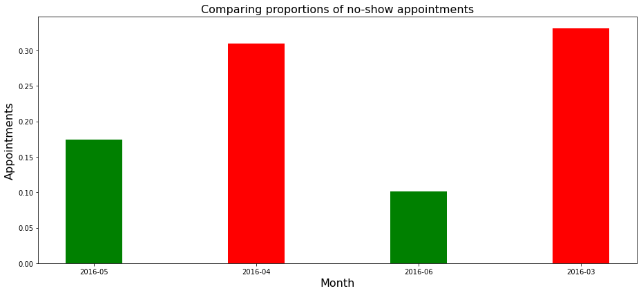

```python
# trimming down selected months to the period of March to June
df_march_june_total = df['year_month'].value_counts()[:-4]
df_march_june_noshow = df['year_month'][noshow].value_counts()[:-3]
proportions = df_march_june_noshow / df_march_june_total

labels = list(proportions.index)

x = np.arange(len(labels))  # the label locations
width = 0.35  # the width of the bars

fig, ax = plt.subplots(figsize=(13,6))
rects1 = ax.bar(x, proportions.values, color=['green', 'red'], width=width)

# Add some text for labels, title and custom x-axis tick labels, etc.
ax.set_ylabel('Appointments', fontdict={'fontsize':16})
ax.set_xlabel('Month', fontdict={'fontsize':16})
ax.set_title('Comparing proportions of no-show appointments', fontdict={'fontsize':16})
ax.set_xticks(ticks=x, labels=labels)

fig.tight_layout()

plt.show()
```

- By comparing the proportions of noshow appointments of the selected months, it shows that the proportions of no-show appointments in March and April are remarkably higher than May and June.

### What is the range of age that shows the highest proportions of no-show appointments?

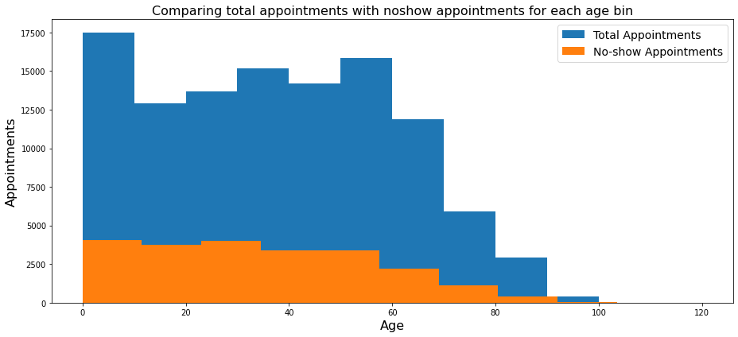

```python
age_bins = np.arange(start=0, stop=130, step=10) # fixed bins for ages

fig, ax = plt.subplots(figsize=(13,6))
rects1 = ax.hist(df['Age'], bins=age_bins, label='Total Appointments')
rects2 = ax.hist(df['Age'][noshow], label='No-show Appointments')

# Add some text for labels, title and custom x-axis tick labels, etc.
ax.set_ylabel('Appointments', fontdict={'fontsize':16})
ax.set_xlabel('Age', fontdict={'fontsize':16})
ax.set_title('Comparing total appointments with noshow appointments for each age bin', fontdict={'fontsize':16})
ax.legend(fontsize=14)

fig.tight_layout()

plt.show()
```

- We can exclude ages above 90 since their total appointments count is low

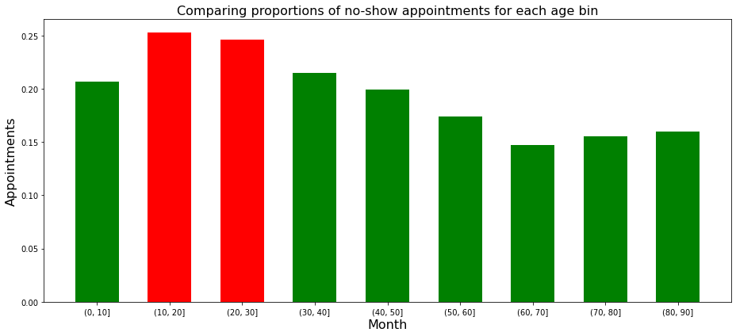

```python
# matching each age to a bin
age_bin_matches = pd.cut(df['Age'], bins=age_bins)
# calculating proportions of no-show appointments for each bin
noshow_proportions_per_age = (age_bin_matches[noshow].value_counts() / age_bin_matches.value_counts())
# Excluding ages over 90
noshow_proportions_per_age = noshow_proportions_per_age[:-3]

# prepare labels
labels = list(noshow_proportions_per_age.index)

x = np.arange(len(labels))  # labels locations
width = 0.6  # the width of the bars

# create figure
fig, ax = plt.subplots(figsize=(13,6))
rects1 = ax.bar(x, noshow_proportions_per_age.values, width=width, color=['green', 'red', 'red', 'green', 'green', 'green', 'green', 'green'])

# Add some text for labels, title and custom x-axis tick labels, etc.
ax.set_ylabel('Appointments', fontdict={'fontsize':16})
ax.set_xlabel('Month', fontdict={'fontsize':16})
ax.set_title('Comparing proportions of no-show appointments for each age bin', fontdict={'fontsize':16})
ax.set_xticks(ticks=x, labels=labels)

fig.tight_layout()

plt.show()
```

- We can see that the age range from 10 to 30 has the highest proportion of no-show appointments.

### Are there specific conditions of patients significantly associated with no-show appointments?

#### Proportions of appointments of patients who have diabetes across no-show appointments:

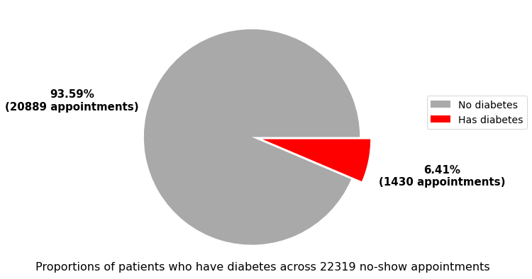

```python
# used examples from matplotlib docs
# https://matplotlib.org/stable/gallery/pie_and_polar_charts/pie_and_donut_labels.html#sphx-glr-gallery-pie-and-polar-charts-pie-and-donut-labels-py
# https://matplotlib.org/stable/gallery/pie_and_polar_charts/pie_features.html#sphx-glr-gallery-pie-and-polar-charts-pie-features-py

fig, ax = plt.subplots(figsize=(8, 7), subplot_kw=dict(aspect="equal"))

# chart data and legend labels
data = df['Diabetes'][noshow].value_counts()
data_count = data.sum()
labels = ['No diabetes', 'Has diabetes']

# create the chart
wedges, texts, autotexts = ax.pie(data,
                                  # output the percentage along with the actual number of appointments
                                  autopct=lambda pct: str(round(pct, 2)) + "%\n(" + str(round(pct * data_count / 100)) + " appointments)",
                                  pctdistance=1.7, # distance of percentage text from center
                                  textprops=dict(color='black'), # color of percentage text
                                  colors=['darkgrey', 'red'], # colors of proportions in the chart in order
                                  explode=(.1,0) # make the important proportion stick out
                                 )

# set legend
ax.legend(
    wedges,
    labels,
    fontsize=14,
    loc="right",
    bbox_to_anchor=(1, 0, 0.5, 1.2) # position of legend
)

# edit the font of percentage text
plt.setp(autotexts, size=15, weight="bold")

# set chart title
ax.set_title(
    f"Proportions of patients who have diabetes across {data_count} no-show appointments",
    y=0, # put the title at the bottom of the chart
    fontdict={'fontsize': 16}
)

plt.show()
```

#### Proportions of appointments of patients enrolled in Bolsa Familia welfare program across no-show appointments:

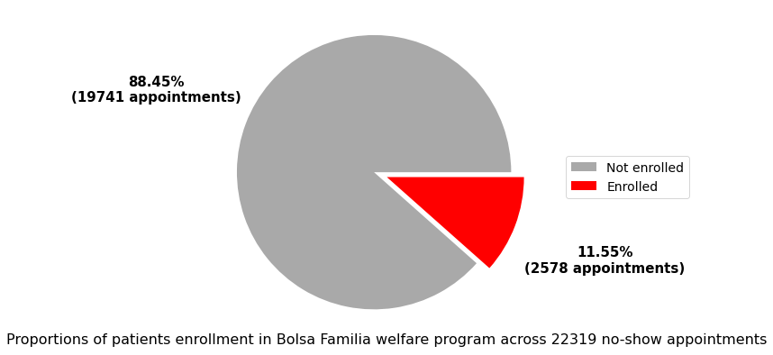

```python
# used examples from matplotlib docs
# https://matplotlib.org/stable/gallery/pie_and_polar_charts/pie_and_donut_labels.html#sphx-glr-gallery-pie-and-polar-charts-pie-and-donut-labels-py
# https://matplotlib.org/stable/gallery/pie_and_polar_charts/pie_features.html#sphx-glr-gallery-pie-and-polar-charts-pie-features-py

fig, ax = plt.subplots(figsize=(8, 7), subplot_kw=dict(aspect="equal"))

# chart data and legend labels
data = df['Scholarship'][noshow].value_counts()
data_count = data.sum()
labels = ['Not enrolled', 'Enrolled']

# create the chart
wedges, texts, autotexts = ax.pie(data,
                                  # output the percentage along with the actual number of appointments
                                  autopct=lambda pct: str(round(pct, 2)) + "%\n(" + str(round(pct * data_count / 100)) + " appointments)",
                                  pctdistance=1.7, # distance of percentage text from center
                                  textprops=dict(color='black'), # color of percentage text
                                  colors=['darkgrey', 'red'], # colors of proportions in the chart in order
                                  explode=(.1,0) # make the important proportion stick out
                                 )

# set legend
ax.legend(wedges,
          labels,
          fontsize=14,
          loc="right",
          bbox_to_anchor=(0.9, 0, 0.5, 1) # position of legend
         )

# edit the font of percentage text
plt.setp(autotexts, size=15, weight="bold")

# set chart title
ax.set_title(
    f"Proportions of patients enrollment in Bolsa Familia welfare program across {data_count} no-show appointments",
    y=0, # put the title at the bottom of the chart
    fontdict={'fontsize': 16}
)

plt.show()
```

#### Proportions of appointments of patients who have hypertension across no-show appointments:

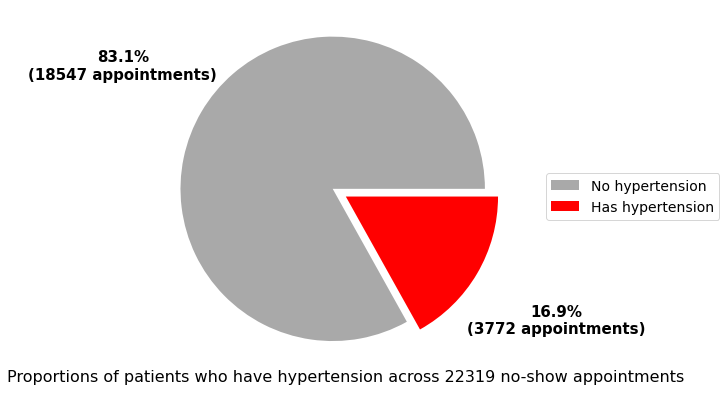

```python
# used examples from matplotlib docs
# https://matplotlib.org/stable/gallery/pie_and_polar_charts/pie_and_donut_labels.html#sphx-glr-gallery-pie-and-polar-charts-pie-and-donut-labels-py
# https://matplotlib.org/stable/gallery/pie_and_polar_charts/pie_features.html#sphx-glr-gallery-pie-and-polar-charts-pie-features-py

fig, ax = plt.subplots(figsize=(8, 7), subplot_kw=dict(aspect="equal"))

# chart data and legend labels
data = df['Hypertension'][noshow].value_counts()
data_count = data.sum()
labels = ['No hypertension', 'Has hypertension']

# create the chart
wedges, texts, autotexts = ax.pie(data,
                                  # output the percentage along with the actual number of appointments
                                  autopct=lambda pct: str(round(pct, 2)) + "%\n(" + str(round(pct * data_count / 100)) + " appointments)",
                                  pctdistance=1.6, # distance of percentage text from center
                                  textprops=dict(color='black'), # color of percentage text
                                  colors=['darkgrey', 'red'], # colors of proportions in the chart in order
                                  explode=(.1,0) # make the important proportion stick out
                                 )

# set legend
ax.legend(wedges,
          labels,
          fontsize=14,
          loc="right",
          bbox_to_anchor=(1, 0, 0.5, 1) # position of legend
         )

# edit the font of percentage text
plt.setp(autotexts, size=15, weight="bold")

# set chart title
ax.set_title(
    f"Proportions of patients who have hypertension across {data_count} no-show appointments",
    y=0, # put the title at the bottom of the chart
    fontdict={'fontsize': 16}
)

plt.show()
```

### Is there a lack of SMS messages associated with no-show appointments?

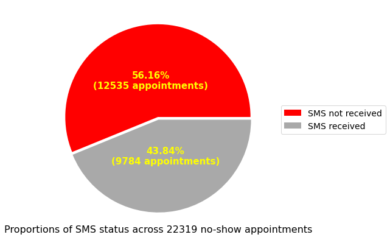

```python
# used examples from matplotlib docs
# https://matplotlib.org/stable/gallery/pie_and_polar_charts/pie_and_donut_labels.html#sphx-glr-gallery-pie-and-polar-charts-pie-and-donut-labels-py
# https://matplotlib.org/stable/gallery/pie_and_polar_charts/pie_features.html#sphx-glr-gallery-pie-and-polar-charts-pie-features-py

fig, ax = plt.subplots(figsize=(8, 7), subplot_kw=dict(aspect="equal"))

# chart data and legend labels
data = df['SMS_received'][noshow].value_counts()
data_count = data.sum()
labels = ['SMS not received', 'SMS received']

# create the chart
wedges, texts, autotexts = ax.pie(data,
                                  # output the percentage along with the actual number of appointments
                                  autopct=lambda pct: str(round(pct, 2)) + "%\n(" + str(round(pct * data_count / 100)) + " appointments)",
                                  pctdistance=0.4, # distance of percentage text from center
                                  textprops=dict(color='yellow'), # color of percentage text
                                  colors=['red', 'darkgrey'], # colors of proportions in the chart in order
                                  explode=(.03,0) # make the important proportion stick out
                                 )

# set legend
ax.legend(wedges,
          labels,
          fontsize=14,
          loc="right",
          bbox_to_anchor=(1, 0, 0.5, 1) # position of legend
         )

# edit the font of percentage text
plt.setp(autotexts, size=15, weight="bold")

# set chart title
ax.set_title(
    f"Proportions of SMS status across {data_count} no-show appointments",
    y=0, # put the title at the bottom of the chart
    fontdict={'fontsize': 16}
)

plt.show()
```